# Lab 5

Elke Windschitl & Lewis White

2023-02-08

This week’s lab is a musical lab. You’ll be requesting data from the Spotify API and using it to build k-nearest neighbor and decision tree models.

In order to use the Spotify you must have a Spotify account. If you don’t have one, sign up for a free one here: https://www.spotify.com/us/signup

Once you have an account, go to Spotify for developers (https://developer.spotify.com/) and log in. Click the green “Create a Client ID” button to fill out the form to create an app create an app so you can access the API.

On your developer dashboard page, click on the new app you just created. On the app’s dashboard page you will find your Client ID just under the header name of your app. Click “Show Client Secret” to access your secondary Client ID. When you do this you’ll be issued a Spotify client ID and client secret key.

**Classify by users**. Build models that predict whether a given song will be in your collection vs. a partner in class. This requires that you were already a Spotify user so you have enough data to work with. You will download your data from the Spotify API and then exchange with another member of class.

```r
# Load libraries
library(spotifyr) #API interaction
library(tidyverse)
library(tidymodels)
library(rsample)
library(recipes)
library(skimr)
library(kknn)
library(hrbrthemes)
library(viridis)
library(workflows)
```

Client ID and Client Secret are required to create and access token that is required to interact with the API. You can set them as system values so we don’t have to do provide them each time.

Sys.setenv(SPOTIFY_CLIENT_ID = ‘59332ee4fe624c2b8eeac564ae89bd85’) Sys.setenv(SPOTIFY_CLIENT_SECRET = ‘52a6d127938542cd9e2886a1133457e7’)

```r
access_token <- get_spotify_access_token() #takes ID and SECRET, sends to Spotify and receives an access token
```

> *This may result in an error:*

> INVALID_CLIENT: Invalid redirect URI

> *This can be resolved by editing the callback settings on your app. Go to your app and click “Edit Settings”. Under redirect URLs paste this: http://localhost:1410/ and click save at the bottom.*

## **Data Preparation**

You can use get_my_saved_tracks() to request all your liked tracks. It would be good if you had at least 150-200 liked tracks so the model has enough data to work with. If you don’t have enough liked tracks, you can instead use get_my_recently_played(), and in that case grab at least 500 recently played tracks if you can.

The Spotify API returns a dataframe of tracks and associated attributes. However, it will only return up to 50 (or 20) tracks at a time, so you will have to make multiple requests. Use a function to combine all your requests in one call.

```r
# Get first 50 songs
my_songs <- get_my_saved_tracks(limit = 50)

# for each set of 50 songs, bind to my_songs
for(i in seq(50, 450, 50)) {
  songs <- get_my_saved_tracks(limit = 50, offset(i))
  my_songs <- rbind(my_songs, songs)
}

#selecting the track id and track name from liked tracks so I can use left_join and only add the track name to the audio features data set
my_songs_for_joining <- my_songs %>%
  select(track.id, track.name, track.artists) %>%
  mutate(primary_artist = unlist(lapply(my_songs$track.artists,
                                        function(x) x$name[1]))) %>%
  select(-track.artists)
```

Once you have your tracks, familiarize yourself with this initial dataframe. You’ll need to request some additional information for the analysis. If you give the API a list of track IDs using get_track_audio_features(), it will return an audio features dataframe of all the tracks and some attributes of them.

```r
# Initiate empty song features vector
song_features <- c()

# Retreive the song features on track.id for all songs
for(i in seq(1, 401, 100)) {
  feats <- get_track_audio_features(my_songs$track.id[seq(i, (i + 99), 1)])
  song_features <- rbind(song_features, feats)
}

# Bind song names to track features
song_features <- cbind(song_features, my_songs_for_joining) %>%
  select(-track.id)

#write_csv(song_features, "elke_liked_tracks.csv")
```

These track audio features are the predictors we are interested in, but this dataframe doesn’t have the actual names of the tracks. Append the ‘track.name’ column from your favorite tracks database.

Find a class mate whose data you would like to use. Add your partner’s data to your dataset. Create a new column that will contain the outcome variable that you will try to predict. This variable should contain two values that represent if the track came from your data set or your partner’s.

```r
lewis_liked_tracks <- read_csv("lewis_liked_tracks.csv") %>%
  mutate(listener = "Lewis")
elke_liked_tracks <- song_features %>%
  mutate(listener = "Elke")

all_tracks <- rbind(lewis_liked_tracks, elke_liked_tracks) %>%
  select(-(type:analysis_url)) #remove unnecessary columns
```

## Data Exploration

Let’s take a look at your data. Do some exploratory summary stats and visualization.

For example: What are the most danceable tracks in your dataset? What are some differences in the data between users?

**From the brief (and non-exhaustive) exploration below, we can see that Lewis on average listens to songs that are more danceable, energetic, and speechy than me. I tend to listen to songs that are more acoustic than Lewis. Also, I listen to slightly longer songs than Lewis. There is not a significant difference (at a significance level of 0.05) between the instrumentalness of the songs that Lewis and I listen to.**

```r
# Sort and find my top 5 artists
sorted_table_e <- sort(table(elke_liked_tracks$primary_artist), decreasing = TRUE)
top_five_artists_e <- sorted_table_e[1:5]
print(top_five_artists_e)
```

```
##
##    Noah Kahan  Taylor Swift   Miley Cyrus    Lord Huron The Lumineers
##            58            34            25            16            12
```

```r
# Sort and find lewis's top 5 artists
sorted_table_l <- sort(table(lewis_liked_tracks$primary_artist), decreasing = TRUE)
top_five_artists_l <- sorted_table_l[1:5]
print(top_five_artists_l)
```

```
##
##     Lana Del Rey     BROCKHAMPTON       Kanye West Childish Gambino
##               48               22               20               18
##            Drake
##               18
```

```r
# Find my most danceable songs
dancable <- elke_liked_tracks %>%
  arrange(desc(danceability)) %>%
  slice(1:5)
print(dancable[,c("track.name", "danceability")])
```

```
##                                              track.name danceability
## 1 This Must Be the Place (Naive Melody) - 2005 Remaster        0.942
## 2                       WAP (feat. Megan Thee Stallion)        0.935
## 3                                                   4x4        0.925
## 4                     Let Me Down (with Chelsea Cutler)        0.843
## 5                                                Gnarly        0.841
```

```r
# Find my most acoustic songs
acoustic <- elke_liked_tracks %>%
  arrange(desc(acousticness)) %>%
  slice(1:5)
print(acoustic[,c("track.name", "acousticness")])
```

```
##   track.name acousticness
## 1      saman        0.994
## 2  That Home        0.991
## 3      Wash.        0.990
## 4  Interlude        0.988
## 5     Wolves        0.972
```

```r
# Find my highest energy songs
energy <- elke_liked_tracks %>%
  arrange(desc(energy)) %>%
  slice(1:5)
print(energy[,c("track.name", "energy")])
```

```
##                               track.name energy
## 1                                    Sex  0.974
## 2                      All Day All Night  0.946
## 3 Sunday Bloody Sunday - Remastered 2008  0.944
## 4        Go Your Own Way - 2004 Remaster  0.941
## 5                              Chocolate  0.938
```

```r
# Find my speechiest songs
speechy <- elke_liked_tracks %>%
  arrange(desc(speechiness)) %>%
  slice(1:5)
print(speechy[,c("track.name", "speechiness")])
```

```
##                        track.name speechiness
## 1                      Dirty AF1s       0.385
## 2 WAP (feat. Megan Thee Stallion)       0.375
## 3                    October Eyes       0.367
## 4                           WOMAN       0.361
## 5       Roxanne - Remastered 2003       0.354
```

```r
# Find my livest songs
liveness <- elke_liked_tracks %>%
  arrange(desc(liveness)) %>%
  slice(1:5)
print(liveness[,c("track.name", "liveness")])
```

```
##             track.name liveness
## 1 Rhiannon - Live 2005    0.985
## 2    Twenty Long Years    0.926
## 3        Dancing Queen    0.760
## 4            Landslide    0.699
## 5     The Night We Met    0.641
```

```r
# Find my highest tempo songs
tempo <- elke_liked_tracks %>%
  arrange(desc(tempo)) %>%
  slice(1:5)
print(tempo[,c("track.name", "tempo")])
```

```
##                                track.name   tempo
## 1                                      FU 190.097
## 2                                   10/10 187.783
## 3                    Tusk - 2015 Remaster 180.837
## 4                             Unthinkable 180.068
## 5 Dusk Till Dawn (feat. Sia) - Radio Edit 180.042
```

```r
# Find my longest songs
length <- elke_liked_tracks %>%
  arrange(desc(duration_ms)) %>%
  slice(1:5)
print(length[,c("track.name", "duration_ms")])
```

```
##                                                             track.name
## 1                                                          Time's Blur
## 2 All Too Well (10 Minute Version) (Taylor's Version) (From The Vault)
## 3                                                 Rhiannon - Live 2005
## 4                                                    Show Them The Way
## 5                        This Bitter Earth / On The Nature Of Daylight
##   duration_ms
## 1      858291
## 2      613027
## 3      421800
## 4      391332
## 5      372747
```

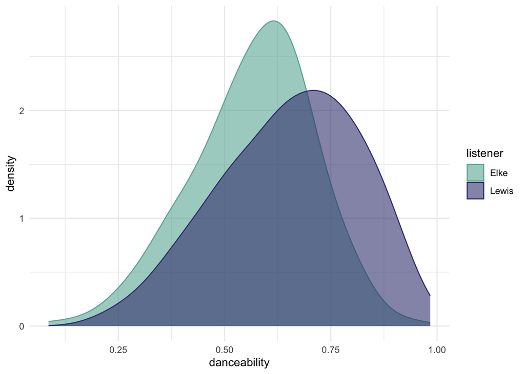

```r
# Danceablility Plot
ggplot(data = all_tracks, aes(x = danceability, color = listener, fill= listener)) +
  geom_density(adjust=1.5, alpha=.6) +
  theme_minimal() +
  scale_fill_manual(values = c("#69b3a2", "#404080")) +
  scale_color_manual(values = c("#69b3a2", "#404080"))
```

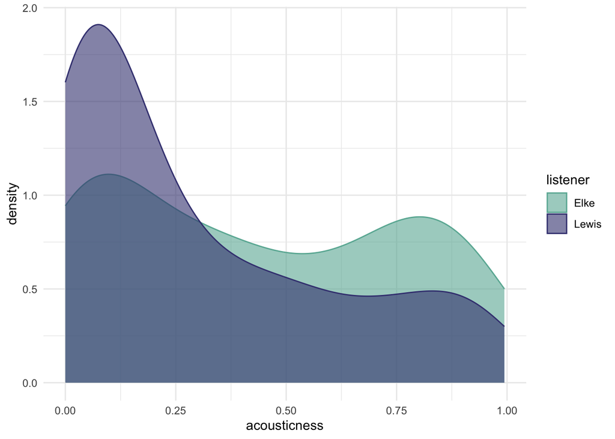

```r
# Acousitcness Plot
ggplot(data = all_tracks, aes(x = acousticness, color = listener, fill= listener)) +
  geom_density(adjust=1.5, alpha=.6) +
  theme_minimal() +
  scale_fill_manual(values = c("#69b3a2", "#404080")) +
  scale_color_manual(values = c("#69b3a2", "#404080"))
```

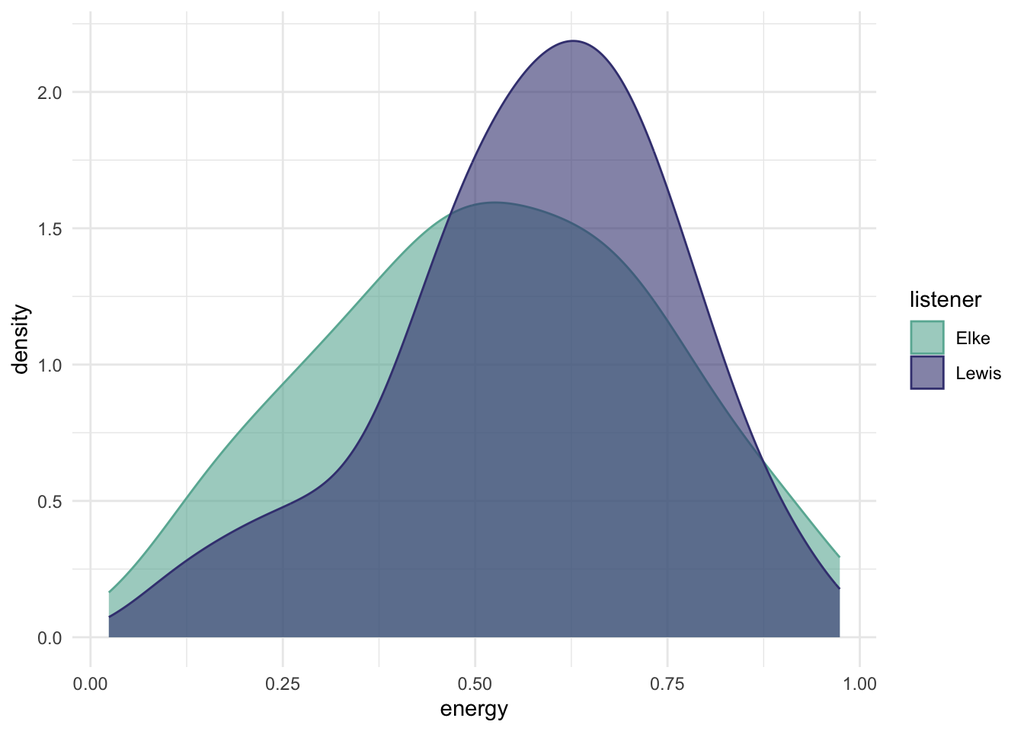

```r
# Energy Plot
ggplot(data = all_tracks, aes(x = energy, color = listener, fill= listener)) +
  geom_density(adjust=1.5, alpha=.6) +
  theme_minimal() +
  scale_fill_manual(values = c("#69b3a2", "#404080")) +
  scale_color_manual(values = c("#69b3a2", "#404080"))
```

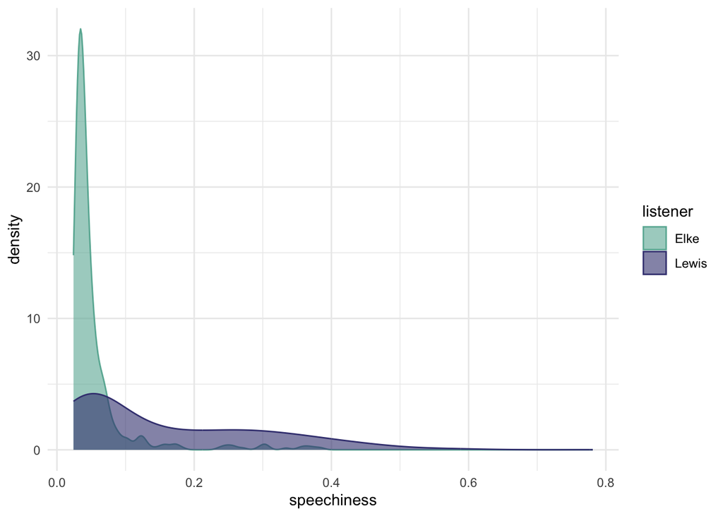

```r
# Speechiness Plot
ggplot(data = all_tracks, aes(x = speechiness, color = listener, fill= listener)) +
  geom_density(adjust=1.5, alpha=.6) +
  theme_minimal() +
  scale_fill_manual(values = c("#69b3a2", "#404080")) +
  scale_color_manual(values = c("#69b3a2", "#404080"))
```

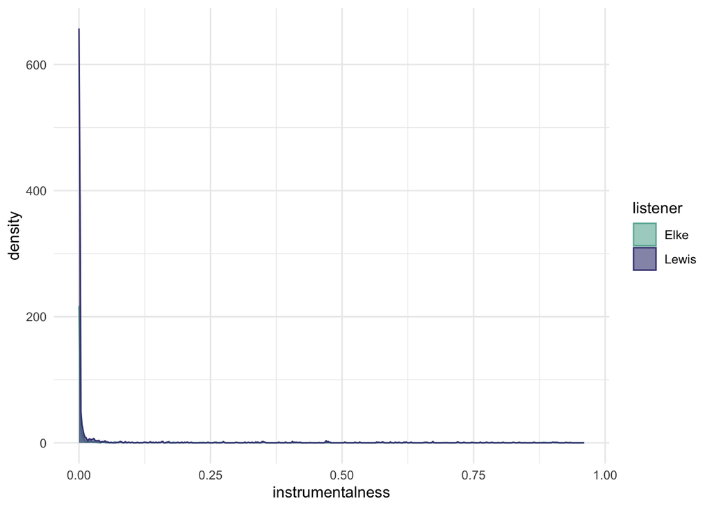

```r
# Instrumentalness Plot
ggplot(data = all_tracks, aes(x = instrumentalness, color = listener, fill= listener)) +
  geom_density(adjust=1.5, alpha=.6) +
  theme_minimal() +
  scale_fill_manual(values = c("#69b3a2", "#404080")) +
  scale_color_manual(values = c("#69b3a2", "#404080"))
```

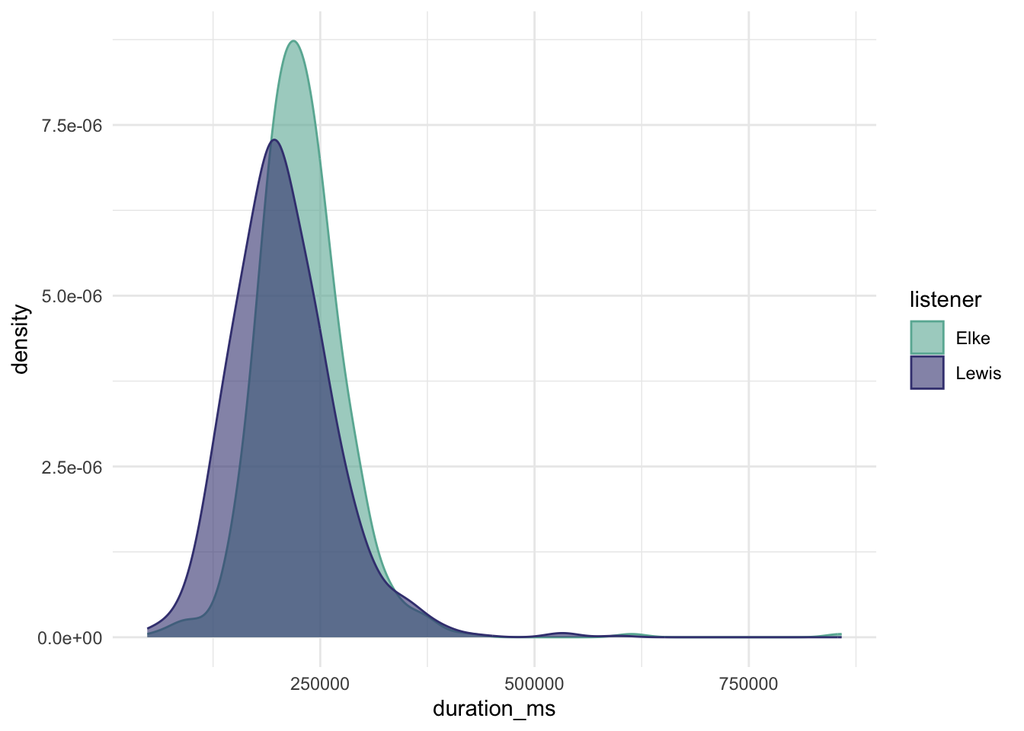

```r
# Duration Plot
ggplot(data = all_tracks, aes(x = duration_ms, color = listener, fill= listener)) +
  geom_density(adjust=1.5, alpha=.6) +
  theme_minimal() +
  scale_fill_manual(values = c("#69b3a2", "#404080")) +
  scale_color_manual(values = c("#69b3a2", "#404080"))
```

```r
# t.test on lewis vs elke danciness
t.test(danceability ~ listener, data = all_tracks)
```

```
##
##  Welch Two Sample t-test
##
## data:  danceability by listener
## t = -10.711, df = 1126.5, p-value < 2.2e-16
## alternative hypothesis: true difference in means between group Elke and group Lewis is not equal to 0
## 95 percent confidence interval:
##  -0.10232873 -0.07064212
## sample estimates:
##  mean in group Elke mean in group Lewis
##           0.5667060           0.6531914
```

```r
# t.test on lewis vs elke acousticness
t.test(acousticness ~ listener, data = all_tracks)
```

```
##
##  Welch Two Sample t-test
##
## data:  acousticness by listener
## t = 7.4069, df = 909.35, p-value = 2.949e-13
## alternative hypothesis: true difference in means between group Elke and group Lewis is not equal to 0
## 95 percent confidence interval:
##  0.09493404 0.16337781
## sample estimates:
##  mean in group Elke mean in group Lewis
##           0.4281137           0.2989578
```

```r
# t.test on lewis vs elke energy
t.test(energy ~ listener, data = all_tracks)
```

```
##
##  Welch Two Sample t-test
##
## data:  energy by listener
## t = -4.8834, df = 860.26, p-value = 1.243e-06
## alternative hypothesis: true difference in means between group Elke and group Lewis is not equal to 0
## 95 percent confidence interval:
##  -0.07615596 -0.03248973
## sample estimates:
##  mean in group Elke mean in group Lewis
##           0.5237322           0.5780550
```

```r
# t.test on lewis vs elke speechiness
t.test(speechiness ~ listener, data = all_tracks)
```

```
##
##  Welch Two Sample t-test
##
## data:  speechiness by listener
## t = -21.402, df = 1498.9, p-value < 2.2e-16
## alternative hypothesis: true difference in means between group Elke and group Lewis is not equal to 0
## 95 percent confidence interval:
##  -0.11260072 -0.09369343
## sample estimates:
##  mean in group Elke mean in group Lewis
##           0.0549194           0.1580665
```

```r
# t.test on lewis vs elke instrumentalness
t.test(instrumentalness ~ listener, data = all_tracks)
```

```
##
##  Welch Two Sample t-test
##
## data:  instrumentalness by listener
## t = 1.8366, df = 801.98, p-value = 0.06664
## alternative hypothesis: true difference in means between group Elke and group Lewis is not equal to 0
## 95 percent confidence interval:
##  -0.001109232  0.033367589
## sample estimates:
##  mean in group Elke mean in group Lewis
##          0.05274085          0.03661167
```

```r
# t.test on lewis vs elke duration
t.test(duration_ms ~ listener, data = all_tracks)
```

```
##
##  Welch Two Sample t-test
##
## data:  duration_ms by listener
## t = 6.8798, df = 1031.7, p-value = 1.038e-11
## alternative hypothesis: true difference in means between group Elke and group Lewis is not equal to 0
## 95 percent confidence interval:
##  15735.27 28293.16
## sample estimates:
##  mean in group Elke mean in group Lewis
##            229269.5            207255.3
```

## **Modeling**

Create four models, a k-nearest neighbor model and a decision tree model that predict whether a track belongs to you or your partner’s collection.

Then validate and compare the performance of the two models you have created.

Make sure to use appropriate resampling to select the best version of each algorithm to compare and some appropriate visualization of your results.

Create three final candidate models:

1. k-nearest neighbor

2. decision tree

3. bagged tree

- bag_tree()
- Use the “times =” argument when setting the engine during model specification to specify the number of trees. The rule of thumb is that 50-500 trees is usually sufficient. The bottom of that range should be sufficient here.

4. random forest

- rand_forest()
- m_try() is the new hyperparameter of interest for this type of model. Make sure to include it in your tuning process

Go through the modeling process for each model:

Preprocessing. You can use the same recipe for all the models you create.

Resampling. Make sure to use appropriate resampling to select the best version created by each algorithm.

Tuning. Find the best values for each hyperparameter (within a reasonable range).

Compare the performance of the four final models you have created.

Use appropriate performance evaluation metric(s) for this classification task. A table would be a good way to display your comparison. Use at least one visualization illustrating your model results.

### K-Nearest Neighbor

```r
# If feature is a factor DON'T order
tracks <- all_tracks %>% mutate_if(is.ordered, .funs = factor, ordered = F) %>%
  select(-track.name)
```

```r
# Preprocessing
tracks_recipe <- recipe(listener ~ ., data = tracks) %>% # listener is outcome variable, use all variables
  step_normalize(all_numeric(), -all_outcomes()) %>% # normalize for knn model
  prep()

# Bake
baked_tracks <- bake(tracks_recipe, tracks)
```

```r
set.seed(123)
#initial split of data, default 70/30
tracks_split <- initial_split(baked_tracks, 0.7)
tracks_test <- testing(tracks_split)
tracks_train <- training(tracks_split)
```

```r
set.seed(123)
# 10-fold CV on the training dataset
cv_folds <-tracks_train %>%
  vfold_cv(v=10) #10 is default
cv_folds
```

```
## #  10-fold cross-validation
## # A tibble: 10 × 2
##    splits            id
##    <list>            <chr>
##  1 <split [976/109]> Fold01
##  2 <split [976/109]> Fold02
##  3 <split [976/109]> Fold03
##  4 <split [976/109]> Fold04
##  5 <split [976/109]> Fold05
##  6 <split [977/108]> Fold06
##  7 <split [977/108]> Fold07
##  8 <split [977/108]> Fold08
##  9 <split [977/108]> Fold09
## 10 <split [977/108]> Fold10
```

```r
# Define our KNN model with tuning
knn_spec_tune <- nearest_neighbor(neighbors = tune()) %>% # tune k
  set_mode("classification") %>%
  set_engine("kknn")

# Check the model
knn_spec_tune
```

```
## K-Nearest Neighbor Model Specification (classification)
##
## Main Arguments:
##   neighbors = tune()
##
## Computational engine: kknn
```

```r
# Define a new workflow
wf_knn_tune <- workflow() %>%
  add_model(knn_spec_tune) %>%
  add_recipe(tracks_recipe)

# Fit the workflow on our predefined folds and hyperparameters
fit_knn_cv <- wf_knn_tune %>%
  tune_grid(
    cv_folds, # does tuning based on folds
    grid = data.frame(neighbors = c(1,5,seq(10,100,10)))) # K=1, K=5, K=10, K=20..., K=100. For each different value for k parameter, model will try it on all folds
```

[output not shown]

[output not shown]

```r
# Check the performance with collect_metrics()
print(n = 24, fit_knn_cv %>% collect_metrics())
```

[output not shown]

```r
# The final workflow for our KNN model
final_wf <-
  wf_knn_tune %>%
  finalize_workflow(select_best(fit_knn_cv))
# Check out the final workflow object
final_wf
```

```
## ══ Workflow ════════════════════════════════════════════════════════════════════
## Preprocessor: Recipe
## Model: nearest_neighbor()
##
## ── Preprocessor ────────────────────────────────────────────────────────────────
## 1 Recipe Step
##
## • step_normalize()
##
## ── Model ───────────────────────────────────────────────────────────────────────
## K-Nearest Neighbor Model Specification (classification)
##
## Main Arguments:
##   neighbors = 50
##
## Computational engine: kknn
```

```r
# Fitting our final workflow
final_fit <- final_wf %>%
  fit(data = tracks_train)
# Examine the final workflow
final_fit
```

```
## ══ Workflow [trained] ══════════════════════════════════════════════════════════
## Preprocessor: Recipe
## Model: nearest_neighbor()
##
## ── Preprocessor ────────────────────────────────────────────────────────────────
## 1 Recipe Step
##
## • step_normalize()
##
## ── Model ───────────────────────────────────────────────────────────────────────
##
## Call:
## kknn::train.kknn(formula = ..y ~ ., data = data, ks = min_rows(50,     data, 5))
##
## Type of response variable: nominal
## Minimal misclassification: 0.2382271
## Best kernel: optimal
## Best k: 50
```

```r
# Fit the model to the test data
tracks_pred <- predict(final_fit, new_data = tracks_test)
# Bind to track dataframe
tracks_final <- cbind(tracks_test, tracks_pred)
# Build a confusion matrix
con_matrix <- tracks_final %>%
  select(listener, .pred_class) %>%
  table()

# print table
con_matrix
```

```
##         .pred_class
## listener Elke Lewis
##    Elke    77    61
##    Lewis   50   277
```

```r
# Calculate dummy classifier
dummy <- nrow(lewis_liked_tracks) / (nrow(lewis_liked_tracks) + nrow(elke_liked_tracks))
print(dummy)
```

```
## [1] 0.6774194
```

```r
# Write over 'final_fit' with this last_fit() approach
final_fit <- final_wf %>% last_fit(tracks_split)
# Collect metrics on the test data!
tibble <- final_fit %>% collect_metrics()
tibble
```

```
## # A tibble: 2 × 4
##   .metric  .estimator .estimate .config
##   <chr>    <chr>          <dbl> <chr>
## 1 accuracy binary         0.761 Preprocessor1_Model1
## 2 roc_auc  binary         0.814 Preprocessor1_Model1
```

```r
final_accuracy <- tibble %>%
  filter(.metric == "accuracy") %>%
  pull(.estimate)

print(paste0("We see here that our k-nearest neighbors model had a higher accuracy at predicting listener than the dummy classifier. The accuracy of the model was ", round(final_accuracy, 3), " and the dummy classifier accuracy was ", round(dummy, 3), "."))
```

```
## [1] "We see here that our k-nearest neighbors model had a higher accuracy at predicting listener than the dummy classifier. The accuracy of the model was 0.761 and the dummy classifier accuracy was 0.677."
```

**We see here that our k-nearest neighbors model had a higher accuracy at predicting listener than the dummy classifier.**

### Decision Tree

```r
#Preprocess the data
listener_rec <- recipe(listener~., data = tracks_train) %>%
  step_dummy(all_nominal(), -all_outcomes(), one_hot = TRUE) %>%
  step_normalize(all_numeric(), -all_outcomes())
```

```r
#Tell the model that we are tuning hyperparams
tree_spec_tune <- decision_tree(
  cost_complexity = tune(),
  tree_depth = tune(),
  min_n = tune()) %>%
  set_engine("rpart") %>%
  set_mode("classification")

tree_grid <- grid_regular(cost_complexity(), tree_depth(), min_n(), levels = 5)

tree_grid
```

```
## # A tibble: 125 × 3
##    cost_complexity tree_depth min_n
##              <dbl>      <int> <int>
##  1    0.0000000001          1     2
##  2    0.0000000178          1     2
##  3    0.00000316            1     2
##  4    0.000562              1     2
##  5    0.1                   1     2
##  6    0.0000000001          4     2
##  7    0.0000000178          4     2
##  8    0.00000316            4     2
##  9    0.000562              4     2
## 10    0.1                   4     2
## # … with 115 more rows
```

```r
wf_tree_tune <- workflow() %>%
  add_recipe(listener_rec) %>%
  add_model(tree_spec_tune)
```

```r
#set up k-fold cv. This can be used for all the algorithms
listener_cv = tracks_train %>%
  vfold_cv(v = 5)
listener_cv
```

```
## #  5-fold cross-validation
## # A tibble: 5 × 2
##   splits            id
##   <list>            <chr>
## 1 <split [868/217]> Fold1
## 2 <split [868/217]> Fold2
## 3 <split [868/217]> Fold3
## 4 <split [868/217]> Fold4
## 5 <split [868/217]> Fold5
```

```r
doParallel::registerDoParallel() #build trees in parallel
#200s
tree_rs <- tune_grid(
  tree_spec_tune,
  listener~.,
  resamples = listener_cv,
  grid = tree_grid,
  metrics = metric_set(accuracy)
)
tree_rs
```

```
## # Tuning results
## # 5-fold cross-validation
## # A tibble: 5 × 4
##   splits            id    .metrics           .notes
##   <list>            <chr> <list>             <list>
## 1 <split [868/217]> Fold1 <tibble [125 × 7]> <tibble [0 × 3]>
## 2 <split [868/217]> Fold2 <tibble [125 × 7]> <tibble [0 × 3]>
## 3 <split [868/217]> Fold3 <tibble [125 × 7]> <tibble [0 × 3]>
## 4 <split [868/217]> Fold4 <tibble [125 × 7]> <tibble [0 × 3]>
## 5 <split [868/217]> Fold5 <tibble [125 × 7]> <tibble [0 × 3]>
```

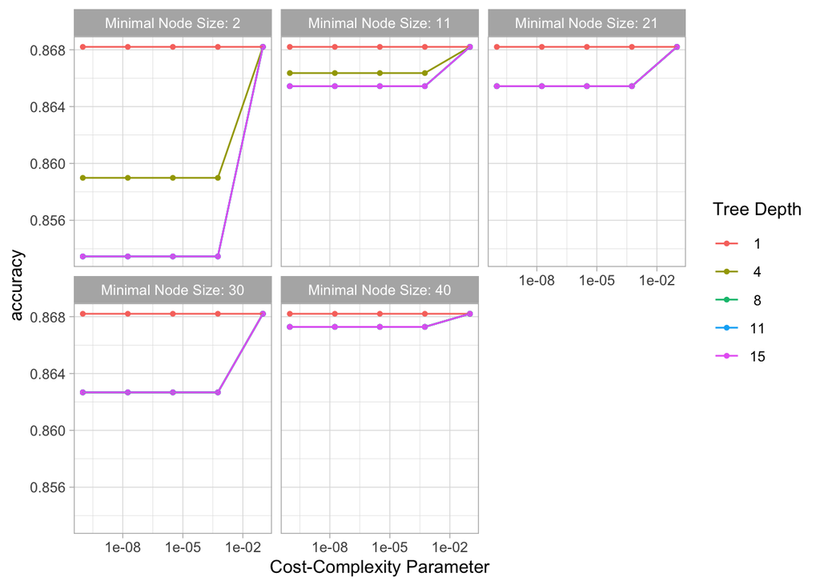

```r
#Use autoplot() to examine how different parameter configurations relate to accuracy
autoplot(tree_rs) + theme_light()
```

```r
# select best hyperparameterw
show_best(tree_rs)
```

```
## # A tibble: 5 × 9
##   cost_complexity tree_depth min_n .metric  .estim…¹  mean     n std_err .config
##             <dbl>      <int> <int> <chr>    <chr>    <dbl> <int>   <dbl> <chr>
## 1    0.0000000001          1     2 accuracy binary   0.868     5 0.00882 Prepro…
## 2    0.0000000178          1     2 accuracy binary   0.868     5 0.00882 Prepro…
## 3    0.00000316            1     2 accuracy binary   0.868     5 0.00882 Prepro…
## 4    0.000562              1     2 accuracy binary   0.868     5 0.00882 Prepro…
## 5    0.1                   1     2 accuracy binary   0.868     5 0.00882 Prepro…
## # … with abbreviated variable name ¹.estimator
```

```r
select_best(tree_rs)
```

```
## # A tibble: 1 × 4
##   cost_complexity tree_depth min_n .config
##             <dbl>      <int> <int> <chr>
## 1    0.0000000001          1     2 Preprocessor1_Model001
```

```r
final_tree <- finalize_model(tree_spec_tune, select_best(tree_rs))
```

```r
final_tree_fit <- last_fit(final_tree, listener~., tracks_split) # does training fit then final prediction as well
final_tree_fit$.predictions
```

```
## [[1]]
## # A tibble: 465 × 6
##    .pred_Elke .pred_Lewis  .row .pred_class listener .config
##         <dbl>       <dbl> <int> <fct>       <fct>    <chr>
##  1     0.0141      0.986      3 Lewis       Lewis    Preprocessor1_Model1
##  2     0.0141      0.986      7 Lewis       Lewis    Preprocessor1_Model1
##  3     0.0141      0.986     12 Lewis       Lewis    Preprocessor1_Model1
##  4     0.939       0.0613    14 Elke        Lewis    Preprocessor1_Model1
##  5     0.0141      0.986     15 Lewis       Lewis    Preprocessor1_Model1
##  6     0.0141      0.986     20 Lewis       Lewis    Preprocessor1_Model1
##  7     0.0141      0.986     21 Lewis       Lewis    Preprocessor1_Model1
##  8     0.0141      0.986     22 Lewis       Lewis    Preprocessor1_Model1
##  9     0.0141      0.986     23 Lewis       Lewis    Preprocessor1_Model1
## 10     0.939       0.0613    27 Elke        Lewis    Preprocessor1_Model1
## # … with 455 more rows
```

```r
final_tree_fit$.metrics
```

```
## [[1]]
## # A tibble: 2 × 4
##   .metric  .estimator .estimate .config
##   <chr>    <chr>          <dbl> <chr>
## 1 accuracy binary         0.875 Preprocessor1_Model1
## 2 roc_auc  binary         0.888 Preprocessor1_Model1
```